# GSE120221 - Human marrow single cell RNA seq: Cell annotation and batch correction integration

# Find the common features of both datasets

```r
common_gene <- base::intersect(df_GSM$genes, df_cd4$genes)
```

# Filter the count matrices to get only common features

```r
not_in_GSM <- base::setdiff(df_GSM$genes, common_gene)
com_genes_df_GSM <- df_GSM %>% arrange(genes) %>% filter(!is.element(genes, not_in_GSM ))
```

```r
not_in_cd4 <- setdiff(df_cd4$genes, common_gene)
com_genes_df_cd4 <- df_cd4 %>% arrange(genes) %>% filter(!is.element(genes, not_in_cd4 ))
```

# Check if we did it right

```r
nrow(com_genes_df_cd4) == nrow(com_genes_df_GSM)
```

```
[1] TRUE
```

```r
setequal(com_genes_df_cd4$genes, com_genes_df_GSM$genes)
```

```
[1] TRUE
```

# Switch back gene column to rowname so we get the count matrix

```r
colnames(com_genes_df_cd4) <- c("genes", as.character(sce_human_marrow$clusters))
com_genes_df_cd4 <- column_to_rownames(com_genes_df_cd4, "genes")
```

# Create singlecellexperiment object

```r
sce_cd4 <- SingleCellExperiment(assays = list(counts = as.matrix(com_genes_df_cd4)))
```

```r
com_genes_df_GSM <- column_to_rownames(com_genes_df_GSM, "genes")
```

```r
sce_GSM <- SingleCellExperiment(assays = list(counts = as.matrix(com_genes_df_GSM)))
```

# Compute the lognormal counts by scuttle library

```r
sce_GSM <- scuttle::logNormCounts(sce_GSM)
sce_cd4 <- scuttle::logNormCounts(sce_cd4)
```

# Run SingleR to annotate cells

# We first make a training for our reference dataset so we can use later for our needed dataset

```r
trained <- trainSingleR(sce_cd4, label=colnames(sce_cd4))
```

# Run the prediction for cells (it takes a while to run the program)

```r
pred <- classifySingleR(sce_GSM, trained)
```

# Assign the predicted cell name to each cell

```r
colnames(sce_GSM) <- pred$labels
```

# Create a copy of seurat object and assign the cluster name by cell types and plot UMAP

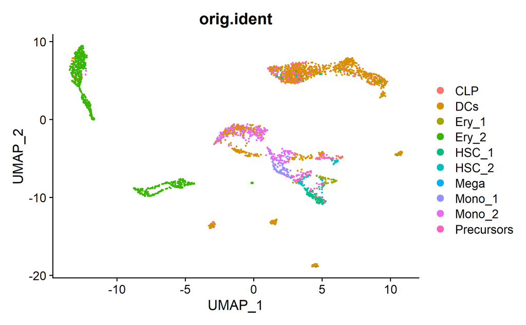

```r
seurat_sce_GSM <- seuratGSM3396161
seurat_sce_GSM$orig.ident <- colnames(sce_GSM)
DimPlot(object = seurat_sce_GSM, reduction = "umap", group.by = "orig.ident", sizes.highlight = TRUE)
```

# Take a look at the frequency of cell types

```r
# seurat_sce_GSM$orig.ident <- colnames(sce_GSM)
table(colnames(sce_GSM))
```

```
       CLP        DCs      Ery_1      Ery_2      HSC_1      HSC_2
        19       1376         50        685        119         69
      Mega     Mono_1     Mono_2 Precursors
        18         84        352        222
```

# Next, we work on a different task. If you have 2 different datasets from 2 difference experience or different batches. We may want to combine 2 dataset as one and we want to minimize the batch effects (batch correction). Here is a way to do it.

# Merge 2 datasets from 2 experiments (You may not need this step but I prefer to merge dataset to get the same features for all datasets first).

# Let us start from creating seurat objects

```r
bone_count <- human_cd34_bone_marrow@assays$RNA@counts

seurat_marrow_cd4 <- CreateSeuratObject(counts = bone_count, project = "bone_cd4")

rownames(count_GSM3396161)<- genes_GSM3396161$symbol
colnames(count_GSM3396161) <- colnames(sce_GSM) # Using the cell names we identify
```

```r
seuratGSM3396161 <- CreateSeuratObject(counts = count_GSM3396161, project = "GSM3396161")
seuratGSM3396161$orig.ident <- colnames(sce_GSM)
```

```r
seurat_marrow_cd4$orig.ident <- as.character(human_cd34_bone_marrow$clusters)
```